# Project: Airlines Delay and Cancellation Analysis

# By (Asmaa Aamer)

## Introduction

### Dataset Description

> This dataset reports flights in the United States, including carriers, arrival and departure delays, and reasons for delays. The goal of this project is to summarize the data by time periods, carriers,airports and understand different factors causing the airline delays and cancellation.

### Asking Questions :

- What is the unique carrier that is cancelled most ?
- what is the most reason that make the cancellation happen ?
- Which month has more cancellation and what is the reason ?
- Which day has the most cancelled flights on ?
- Which day of month has the most flights cancelled ?
- What is the relationship between the Distance and Actual Elapsed Time and Air Time ?
- What is the relationship between the arrival delay and departure delay ?
- Is there a relationship between the Distance and the Arrival Delay ?
- What is the carrier with most delayed flights ?
- Is there a relationship between the Month, Day of month and Day of week with Arrival Delay ?
- What is the cancellation reasons for American Airlines and American Eagel Airlines ?
- What is the cancellation for American Airlines and American Eagel Airlines per month?
- Does the Distance affect the Arrival Delay for the Carrier ?

#### the distrbution of distance with airlines that are cancelled

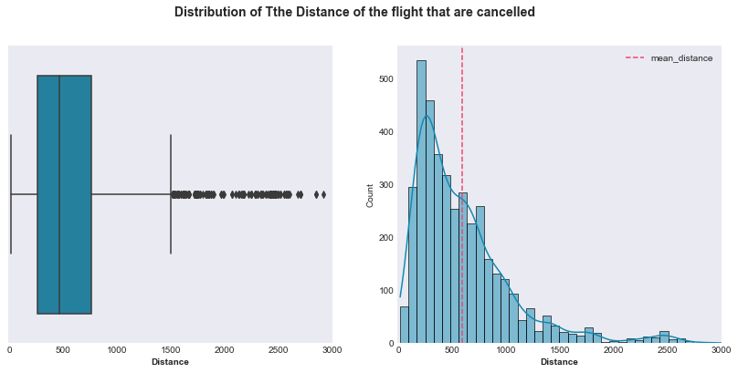

- The histogram is skewed to the right with mean distance around 500 miles.
- More flights cancelled are less than 500 miles which means maybe the short airlines are likely to cancelled more than the long airlines.

#### What is the unique carrier that is cancelled most ?

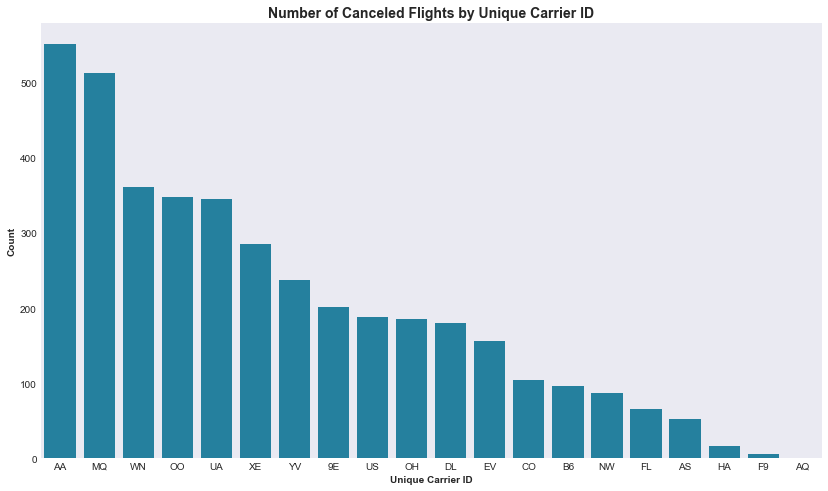

### lets see what is the most reason that make the cancellation happen ?

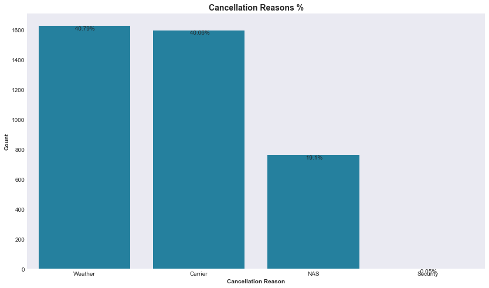

> The most two reasons that affect the cancellation process are **Weather and Carrier** and then the National Air System. And the security dont have affect on the cancellation process

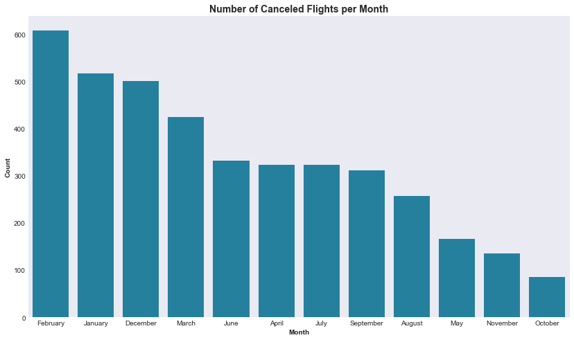

### Which day has the most cancelled flights on ?

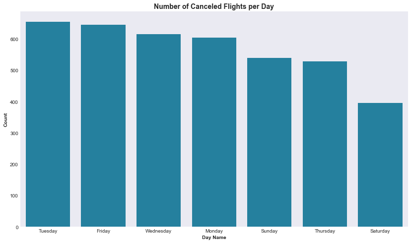

> The most flights cancelled happen in Friday and Tuesday.

### Which day of month has the most flights cancelled ?

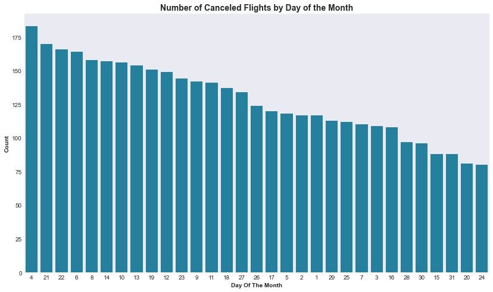

### What is the relationship between the Distance and Actual Elapsed Time and Air Time ?

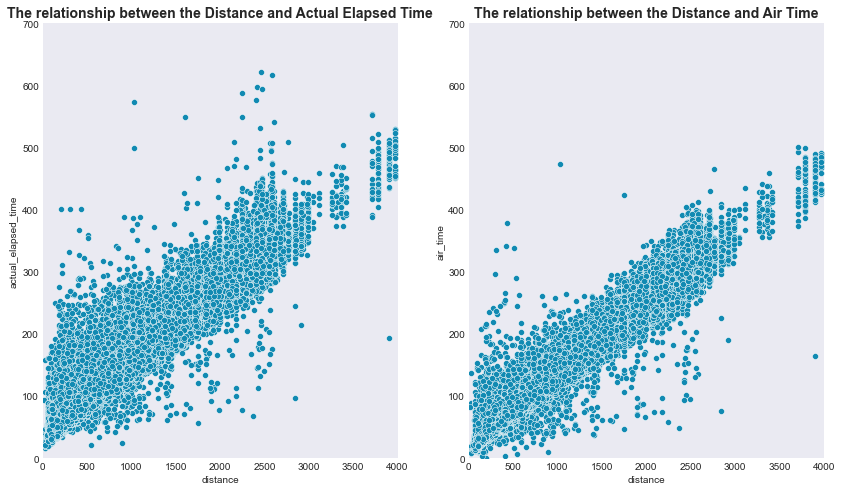

- There is a `Positive correlation` which means if the distance increases both the actual elapsed time and air time will increase.

### What is the relationship between the arrival delay and departure delay ?

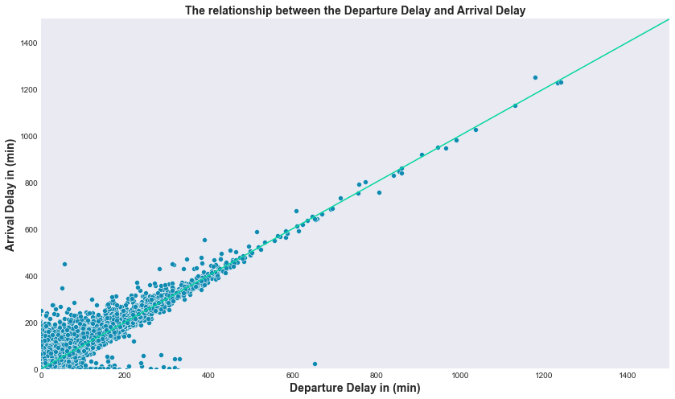

> There is a positive correlation, if the flight going off late absolutely it would arrive late.

### Is there a relationship between the Distance and the Arrival Delay ?

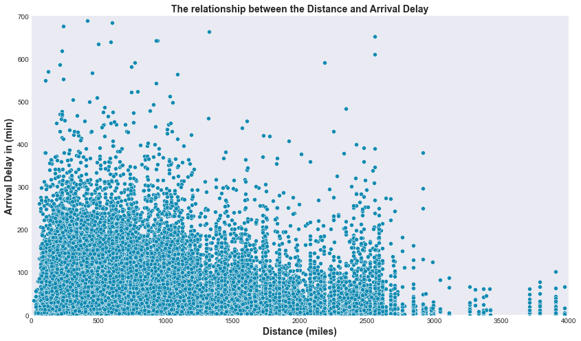

> The flights that has short distance is more likely to delay more than the long distance.

### What is the carrier with most delayed flights ?

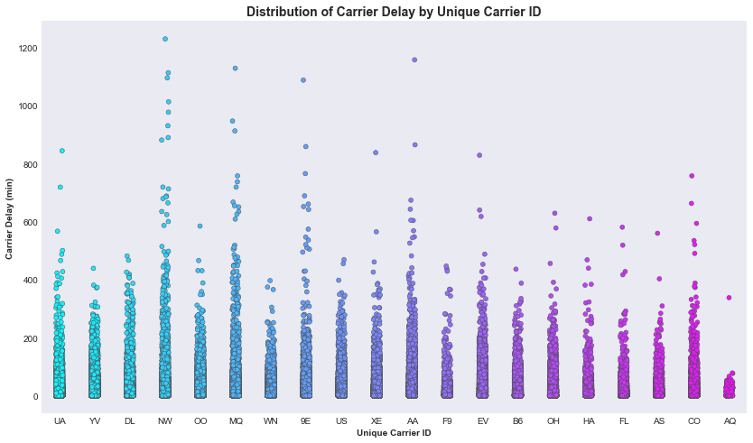

> `Northwest Airlines` has the most delayed flights followed by `American Eagel Airlines` and `American Airlines`

### Is there a relationship between the Month, Day of month and Day of week with Arrival Delay ?

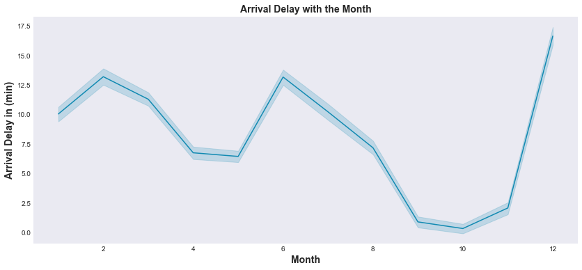

```python
plt.show()
```

- From December to March there is high arrival delay maybe because of the bad weather these months.
- June is too high .
- But from september to November the delay is too small.

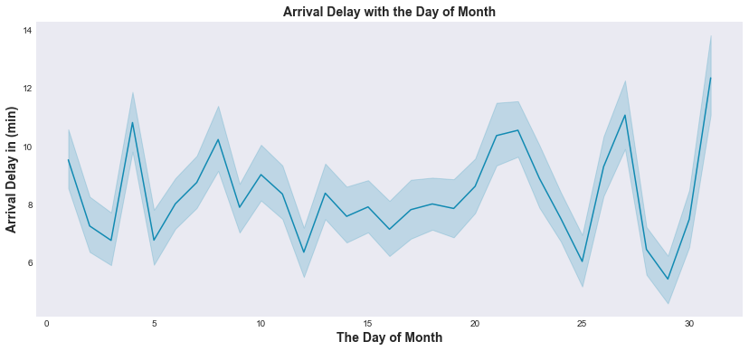

> I see the ups and downs with all the days of the month , so there is not a relationship here.

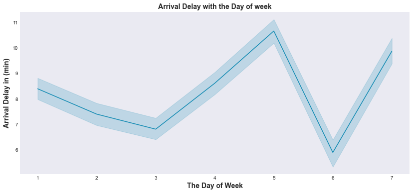

### What is the cancellation reasons for American Airlines and American Eagel Airlines ?

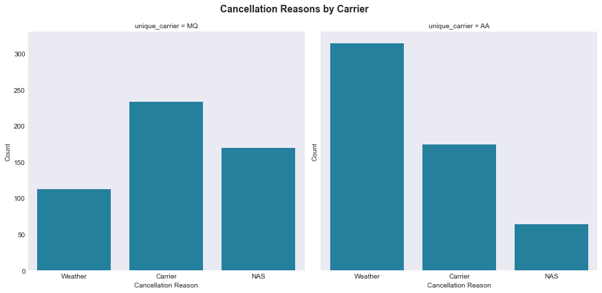

### What is the cancellation for American Airlines and American Eagel Airlines per month?

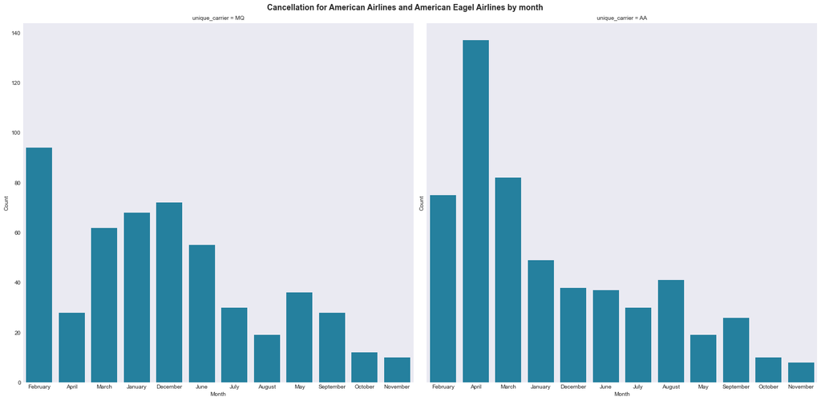

### Does the Distance affect the Arrival Delay for the Carrier ?

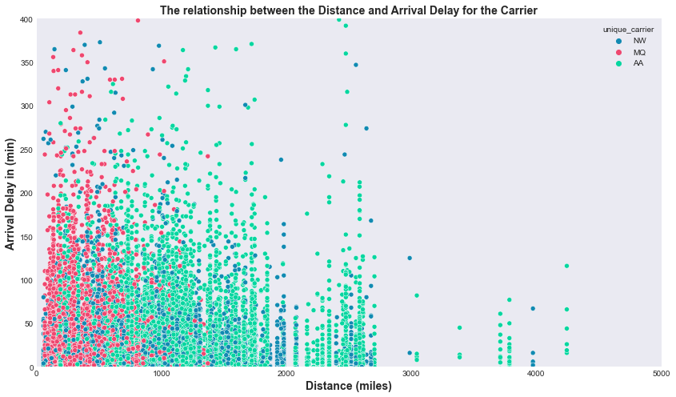

> More Arrival delay happened in short Distance espcially with `MQ Airlines`

### Delayed flights for American Airlines and American Eagel Airlines per month:

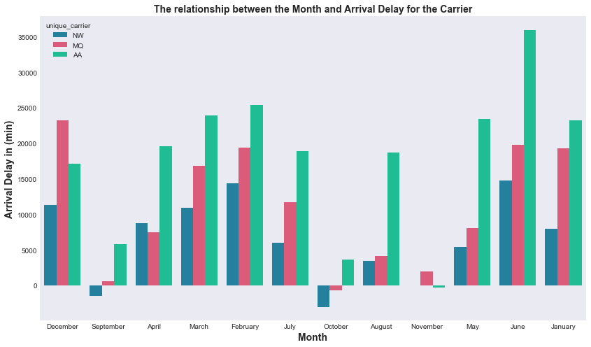